# HW5

2024-12-31

## 作業目標

請任選一位 Youtuber，針對他的影片簡介描述進行以下分析：

1. **文字清理**：
   - 移除不必要的符號、數字及停用詞。
   - 保留關鍵的中文字詞。
2. **文字探勘**：
   - 繪製文字雲。
   - 進行詞頻分析，了解該 Youtuber 使用字詞的習慣。

```r
# Import the data
library(readr)
ytvideo <- read_csv("C:/Users/Ava/Desktop/R/HW5/ytvideo.csv")
View(ytvideo)
```

```r
# import the packages
library(dplyr)
```

```r
library(ggplot2)
library(tm)
library(wordcloud)
library(RColorBrewer)
```

```r
# classification
ytvideo_filtered <- ytvideo %>%
  filter(yt == "蔡阿嘎") %>%
  select(title)
```

這裡我做了兩個版本，一個有用到中文分詞套件，一個沒有。 以下為沒有用到中文分詞套件的版本。

```r
# data cleaning
text_data <- paste(ytvideo_filtered$title, collapse = " ")

clean_text <- text_data %>%
  tolower() %>%
  gsub("[[:punct:]]", " ", .) %>%
  gsub("[^\\p{Han}]", " ", ., perl = TRUE) %>%
  gsub("[0-9]", " ", .) %>%
  gsub("[\\r\\n]", " ", .) %>%
  gsub("\\s+", " ", .) %>%
  trimws()

word_tokens <- unlist(strsplit(clean_text, "\\s+"))
```

```r
# remove stop words
stop_words <- c("的", "是", "了", "在", "我", "也", "和", "有", "這", "他", "她", "就", "不")
filtered_words <- word_tokens[!word_tokens %in% stop_words]
filtered_words
```

```
##   [1] "瘋狂"                           "小時挑戰賽"
##   [3] "台南人都吃這個"                 "直接問台南人"
##   [5] "出賣"                           "間在地美食"
##   [7] "蔡阿嘎"                         "馬叔叔"
##   [9] "食尚玩嘎"                       "澳門賭場上線啦"
##  [11] "蔡阿嘎賭輸賭光流落街頭"         "食尚玩嘎"
##  [13] "到日本環球影城"                 "買破萬元限定商品送大家"
##  [15] "瘋狂"                           "小時挑戰賽"
##  [17] "新竹美食沙漠"                   "直接問路人什麼好吃"
##  [19] "就連去吃"                       "間"
##  [21] "蔡阿嘎"                         "馬叔叔"
##  [23] "嘎慶君遊台灣"                   "元吃一餐"
##  [25] "元在北港玩一整天"               "瘋狂"
##  [27] "小時挑戰賽"                     "一日五塔"
##  [29] "環島台灣五極點"                 "蔡阿嘎"
```

[output cut: 77 more lines]

從這個分詞沒有比較仔細的資料中可以看出，蔡阿嘎的影片可能以旅遊型的為主。

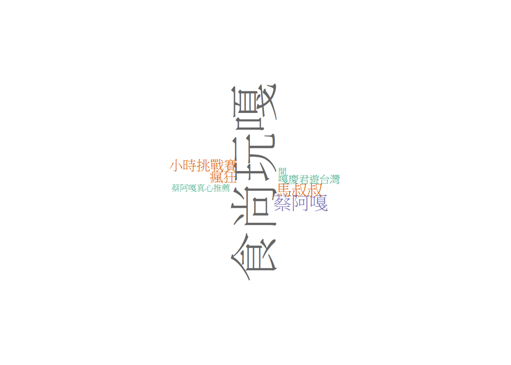

```r
# wordcloud
word_freq <- table(filtered_words)
wordcloud(names(word_freq),
          freq = word_freq,
          min.freq = 2,
          random.order = FALSE,
          colors = brewer.pal(8, "Dark2"))
```

因為分詞沒有整理得太乾淨，所以這裡的文字雲資料顯示的並不多，不過從這個可以看的出來: 1.主題很明顯是以”食尚玩嘎”為標題 2.蔡阿嘎本人的名字也常出現在影片標題中。 3.形式首要是以小時挑戰賽進行，真心推薦為次要。 4.瘋狂出現了好幾次，可能這個影片不像正常旅遊行程。 5.馬叔叔出現了好幾次，經查詢後得知為另一名youtuber，他們可能常常出合作影片。

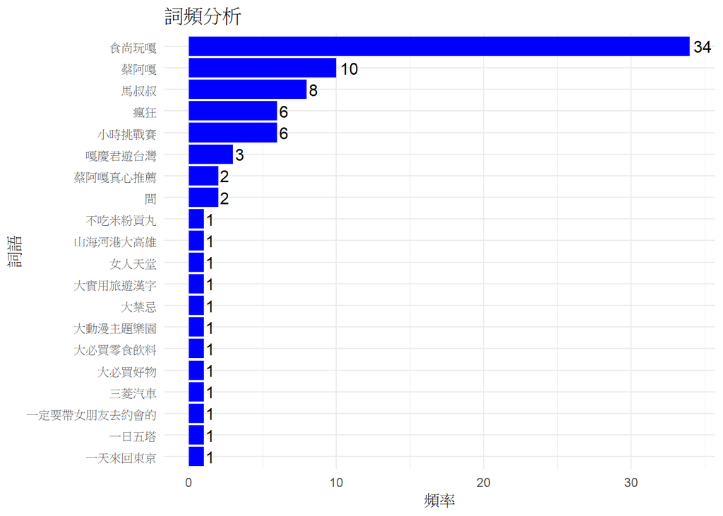

```r
# visualization
word_freq_df <- as.data.frame(word_freq, stringsAsFactors = FALSE)
colnames(word_freq_df) <- c("word", "freq")

top_words <- word_freq_df %>%
  arrange(desc(freq)) %>%
  head(20)

ggplot(top_words, aes(x = reorder(word, freq), y = freq)) +
  geom_bar(stat = "identity", fill = "blue") +
  geom_text(aes(label = freq), hjust = -0.2, size = 4) +
  coord_flip() +
  labs(title = "詞頻分析", x = "詞語", y = "頻率") +
  theme_minimal()
```

以上圖表為字詞出現頻率的長條圖，和文字雲相比，長條圖可以更明顯從圖表中看出實際出現幾次，但文字雲很美觀，可以用在設計和行銷上。

接下來是有用到中文分詞套件的版本

```r
# data cleaning
text_data <- paste(ytvideo_filtered$title, collapse = " ")

clean_text <- text_data %>%
  tolower() %>%
  gsub("[[:punct:]]", " ", .) %>%
  gsub("[^\\p{Han}]", " ", ., perl = TRUE) %>%
  gsub("[0-9]", " ", .) %>%
  gsub("[\\r\\n]", " ", .) %>%
  gsub("\\s+", " ", .) %>%
  trimws()

library(jiebaR)
cutter <- worker()
word_tokens <- cutter[clean_text]
```

```r
# remove stop words
stop_words <- c("的", "是", "了", "在", "我", "也", "和", "有", "這", "他", "她", "就", "不")
filtered_words <- word_tokens[!word_tokens %in% stop_words]
filtered_words
```

```
##   [1] "瘋狂"     "小時"     "挑戰賽"   "台南人"   "都"       "吃"
##   [7] "這個"     "直接"     "問"       "台南人"   "出賣"     "間"
##  [13] "地"       "美食"     "蔡阿嘎"   "馬"       "叔叔"     "食尚"
##  [19] "玩"       "嘎"       "澳門"     "賭場"     "上線"     "啦"
##  [25] "蔡阿嘎"   "賭輸"     "賭光"     "流落"     "街頭"     "食尚"
##  [31] "玩"       "嘎"       "到"       "日本"     "環球"     "影城"
##  [37] "買破"     "萬元"     "限定"     "商品"     "送"       "大家"
##  [43] "瘋狂"     "小時"     "挑戰賽"   "新竹"     "美食"     "沙漠"
##  [49] "直接"     "問路"     "人"       "什麼"     "好吃"     "連去"
##  [55] "吃"       "間"       "蔡阿嘎"   "馬"       "叔叔"     "嘎慶君遊"
##  [61] "台灣"     "元"       "吃"       "一餐"     "元"       "北港"
##  [67] "玩"       "一整天"   "瘋狂"     "小時"     "挑戰賽"   "一日"
##  [73] "五塔"     "環島"     "台灣"     "五"       "極點"     "蔡阿嘎"
##  [79] "馬"       "叔叔"     "水陸"     "鞋"       "瘋狂"     "小時"
##  [85] "挑戰賽"   "一天"     "來回"     "東京"     "完成"     "個"
```

[output cut: 78 more lines]

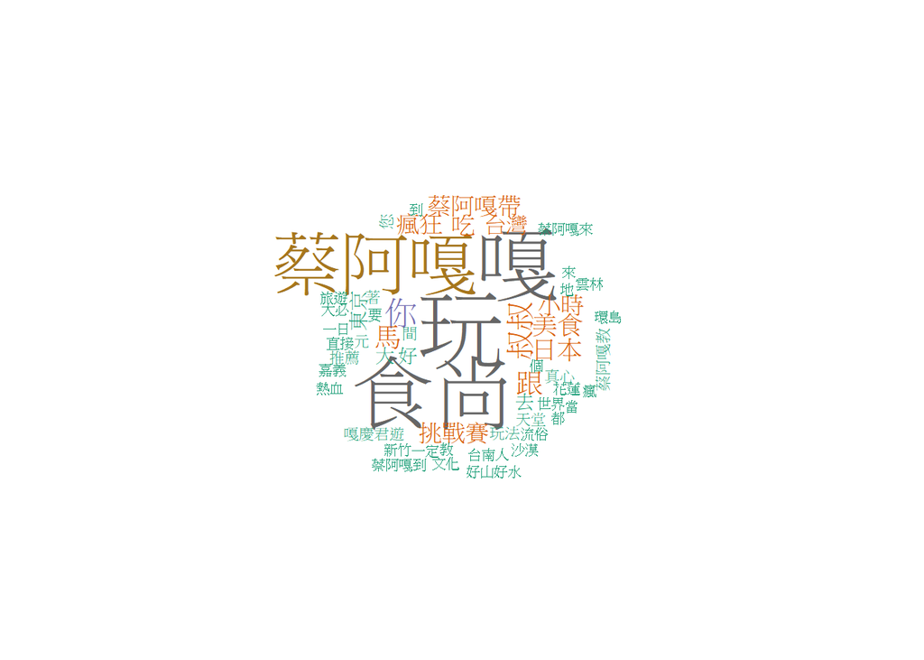

```r
# wordcloud
word_freq <- table(filtered_words)
wordcloud(names(word_freq),
          freq = word_freq,
          min.freq = 2,
          random.order = FALSE,
          colors = brewer.pal(8, "Dark2"))
```

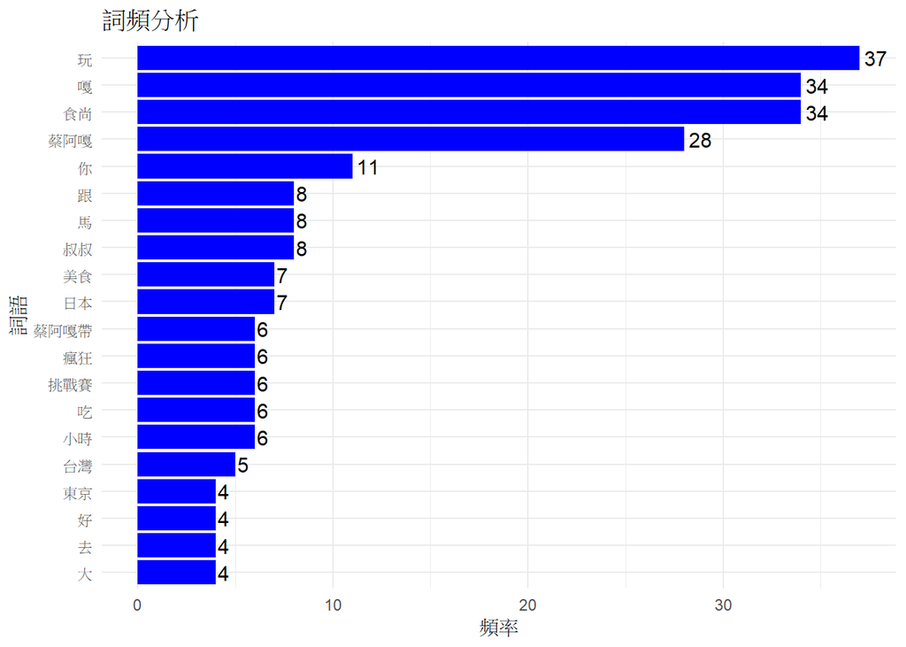

```r
# visualization
word_freq_df <- as.data.frame(word_freq, stringsAsFactors = FALSE)
colnames(word_freq_df) <- c("word", "freq")

top_words <- word_freq_df %>%
  arrange(desc(freq)) %>%
  head(20)

ggplot(top_words, aes(x = reorder(word, freq), y = freq)) +
  geom_bar(stat = "identity", fill = "blue") +
  geom_text(aes(label = freq), hjust = -0.2, size = 4) +
  coord_flip() +
  labs(title = "詞頻分析", x = "詞語", y = "頻率") +
  theme_minimal()
```

仔細切分過後並和前面結果相比，可以發現前幾高的還是食尚玩嘎和蔡阿嘎、馬叔叔等，和前面結果不同的是美食、日本、台灣、東京次數也不算低，由此可知影片選定的旅遊地點可能多在這幾個地方。此外，瘋狂和挑戰賽出現的次數也不少，同樣的也可以看出影片可能並非一般的旅遊vlog。